# ANOVA Vignette

A tutorial on how running an ANOVA in R

# Definitions

**Fixed Variable**: a non-random variable.

- *e.g.*, in an experiment testing the effect of fertilizer on yield, the *fertilizer level* treatment is a fixed variable.

**Random Variable**: a variable whose values depend on outcomes of a random phenomenon.

- *e.g.*, if our experiment testing fertilizer effect on yield was conducted over a number of years at the same site, *year* would be a random variable.

**Fixed Effects Model**: group means are fixed (non-random).

**Random Effects Model**: group means are a random sample from a population.

**Mixed Model**: a statistical model containing both fixed and random effects.

**Analysis of Variance (ANOVA)**: a collection of statistical models and their associated estimation procedures (such as the “variation” among and between groups) used to analyze the differences among group means in a sample. An ANOVA provides a statistical test of whether two or more population means are equal. essentially, it’s a *t*-test for when you want to compare more than two means.

# Prepare Data

```r
# devtools::install_github("derekmichaelwright/dblogr")
library(dblogr) # Loads: tidyverse, ggpubr, ggbeeswarm, ggrepel
library(lme4)
```

```r
pca <- read.csv("data_pca_results.csv")
rr <- read.csv("data_raw.csv") %>%
  left_join(select(pca, Name, Cluster)) %>%
  mutate(Name = factor(Name), Cluster = factor(Cluster),
         Rep = factor(Rep), Year = factor(Year),
         VEG = DTF - DTE) %>%
  filter(!is.na(DTF))
```

# One-way ANOVA

**One-way ANOVA**: used when you have one nominal variable (groups), and one measurement variable.

- *e.g.*, we have 324 genotypes categoriszed into 8 cluster groups, and want to test if these cluster groups are significantly different for days to flower (DTF) in the 2017 field trail in Sutherland, Canada.

$$DTF = \mu + Cluster_i + error_i$$

```r
# Prep data
xx <- rr %>% filter(Location == "Sutherland, Canada", Year == 2017)
# Run ANOVA
model <- lm(DTF ~ Cluster, data = xx)
anova(model)
```

```
## Analysis of Variance Table
##
## Response: DTF
##            Df  Sum Sq Mean Sq F value    Pr(>F)
## Cluster     7 17220.0 2460.00  469.24 < 2.2e-16 ***
## Residuals 937  4912.3    5.24
## ---
## Signif. codes:  0 '***' 0.001 '**' 0.01 '*' 0.05 '.' 0.1 ' ' 1
```

**Interpretation**: p value < 0.05 = at least one of the cluster groups has a mean DTF which is significantly different from the other cluster groups.

However, the fact that at least one of the cluster groups is different from the rest, isn’t very useful. What we may actually want to know, is which ones are different from eachother. To do this, we will need to perform multiple comparisons. but first, lets visualize the data:

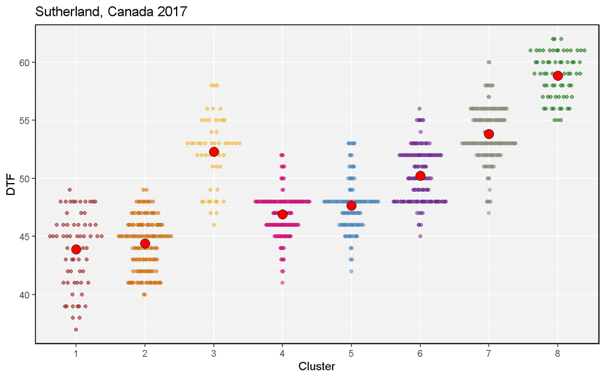

```r
# Prep data
means <- xx %>% group_by(Cluster) %>% summarise(DTF = mean(DTF))
colors <- c("darkred",   "darkorange3", "darkgoldenrod2", "deeppink3",
            "steelblue", "darkorchid4", "cornsilk4",      "darkgreen")
# Plot
ggplot(xx, aes(x = Cluster, y = DTF)) +
  geom_quasirandom(aes(color = Cluster), alpha = 0.5) +
  geom_point(data = means, fill = "red", size = 4, pch = 21) +
  scale_color_manual(values = colors) +
  theme_dblogr(legend.position = "none") +
  labs(title = "Sutherland, Canada 2017")
```

Looking at the data, groups 1 - 2, 4 - 5, and 3 - 7 are the only ones which look like they may **NOT** be significantly different from eachother.

```r
pairwise.t.test(xx$DTF, xx$Cluster, p.adj = "none")
```

```
##
##  Pairwise comparisons using t tests with pooled SD
##
## data:  xx$DTF and xx$Cluster
##
##   1       2       3       4       5       6       7
## 2 0.1471  -       -       -       -       -       -
## 3 < 2e-16 < 2e-16 -       -       -       -       -
## 4 < 2e-16 < 2e-16 < 2e-16 -       -       -       -
## 5 < 2e-16 < 2e-16 < 2e-16 0.0064  -       -       -
## 6 < 2e-16 < 2e-16 2.5e-08 < 2e-16 < 2e-16 -       -
## 7 < 2e-16 < 2e-16 3.1e-05 < 2e-16 < 2e-16 < 2e-16 -
## 8 < 2e-16 < 2e-16 < 2e-16 < 2e-16 < 2e-16 < 2e-16 < 2e-16
##
## P value adjustment method: none
```

Pairwise *t*-tests show that groups 1 - 2 are the only non-significant pair. However, using a p value of 0.05 indicates that there will be a 5% chance of obtaining a false positive with each test. Multiply this accross many pairwise comparisions (tests) and the chances of obtaining false positives increases. In other words, statistical speaking, if one was using compltely random data, for every 20 tests you perform, 1 will be a false positive. Since we just did 28 tests, we can assume at least one might be a false positive. Another way to think of how problematic this is: based on the number of tests we performed, there is almost a garuntee that one test will be significant simply due to the randomness of data.

Luckily, there are a number of statistical approaches to deal with this:

- [Bonfferoni](https://en.wikipedia.org/wiki/Bonferroni_correction)
- [Holm](https://en.wikipedia.org/wiki/Holm%E2%80%93Bonferroni_method)
- [TukeyHSD](https://en.wikipedia.org/wiki/Tukey%27s_range_test)

```r
x<- pairwise.t.test(xx$DTF, xx$Cluster, p.adj = "none")
# Adjust p values using different methods
pAdj <- function(x) {
  as.data.frame(x[[3]]) %>% gather("Group", "p.value", 1:ncol(.)) %>%
    mutate(Group = paste(2:8, Group, sep = "-"),
           p.value = round(p.value, 5)) %>%
    filter(!is.na(p.value))
}
p1 <- pAdj(pairwise.t.test(xx$DTF, xx$Cluster, p.adj = "none"))
p2 <- pAdj(pairwise.t.test(xx$DTF, xx$Cluster, p.adj = "bonf")) %>% rename(bonf=p.value)
p3 <- pAdj(pairwise.t.test(xx$DTF, xx$Cluster, p.adj = "holm")) %>% rename(holm=p.value)
p4 <- TukeyHSD(aov(model))[[1]] %>% as.data.frame() %>% rownames_to_column("Group") %>%
  rename(TukeyHSD=`p adj`) %>% select(Group, TukeyHSD) %>%
  mutate(TukeyHSD = round(TukeyHSD, 5))
pp <- left_join(p1, p2, by = "Group") %>%
  left_join(p3, by = "Group") %>%
  left_join(p4, by = "Group") %>%
  filter(Group %in% c("2-1", "5-4", "7-3"))
pp
```

```
##   Group p.value    bonf    holm TukeyHSD
## 1   2-1 0.14711 1.00000 0.14711  0.83296
## 2   7-3 0.00003 0.00088 0.00009  0.00082
## 3   5-4 0.00644 0.18020 0.01287  0.11467
```

```r
library(agricolae)
HSD.test(model, "Cluster", console = T)
```

```
##
## Study: model ~ "Cluster"
##
## HSD Test for DTF
##
## Mean Square Error:  5.242537
##
## Cluster,  means
##
##        DTF      std   r Min Max
## 1 43.90625 3.170893  64  37  49
## 2 44.40132 2.256000 152  40  49
## 3 52.31373 3.016556  51  46  58
## 4 46.91358 1.846249 162  41  52
## 5 47.66667 2.189867 120  42  53
## 6 50.22297 2.273243 148  45  56
## 7 53.83333 2.270776 180  47  60
## 8 58.83824 1.944071  68  55  62
##
## Alpha: 0.05 ; DF Error: 937
## Critical Value of Studentized Range: 4.296058
##
## Groups according to probability of means differences and alpha level( 0.05 )
##
## Treatments with the same letter are not significantly different.
##
##        DTF groups
## 8 58.83824      a
## 7 53.83333      b
## 3 52.31373      c
## 6 50.22297      d
## 5 47.66667      e
## 4 46.91358      e
## 2 44.40132      f
## 1 43.90625      f
```

Now lets do another with Rep. Unless there is variability within our field, this should be non-significant.

```r
model <- lm(DTF ~ Rep, data = xx)
anova(model)
```

```
## Analysis of Variance Table
##
## Response: DTF
##            Df  Sum Sq Mean Sq F value    Pr(>F)
## Rep         2   876.5  438.23  19.421 5.429e-09 ***
## Residuals 942 21255.8   22.56
## ---
## Signif. codes:  0 '***' 0.001 '**' 0.01 '*' 0.05 '.' 0.1 ' ' 1
```

```r
pairwise.t.test(xx$DTF, xx$Rep, p.adj = "bonf")
```

```
##
##  Pairwise comparisons using t tests with pooled SD
##
## data:  xx$DTF and xx$Rep
##
##   1       2
## 2 0.00014 -
## 3 3.6e-09 0.11004
##
## P value adjustment method: bonferroni
```

Rep 1 is significantly different from Rep 2 & 3.

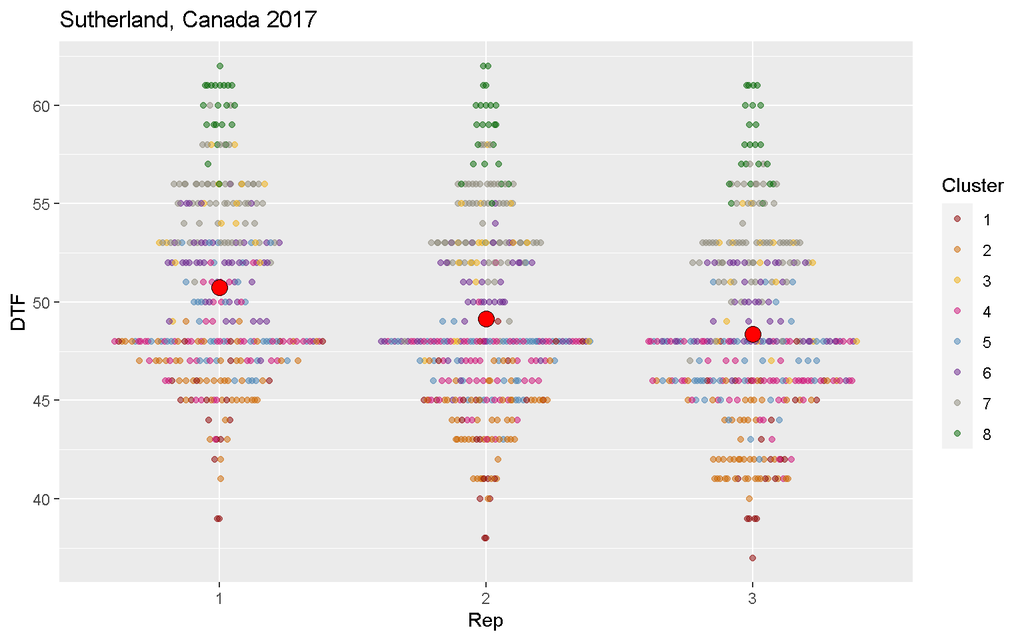

```r
# Plot
means <- xx %>% group_by(Rep) %>% summarise(DTF = mean(DTF))
ggplot(xx, aes(x = Rep, y = DTF)) +
  geom_quasirandom(aes(color = Cluster), alpha = 0.5) +
  geom_point(data = means, fill = "red", size = 4, pch = 21) +
  scale_color_manual(values = colors) +
  labs(title = "Sutherland, Canada 2017")
```

Looking at the data, Rep 1 does seem slightly different from Rep 2 and 3.

Now let try another year - 2018:

```r
# Prep data
xx <- rr %>% filter(Location == "Sutherland, Canada", Year == 2018)
# Run ANOVA
model <- lm(DTF ~ Rep, data = xx)
anova(model)
```

```
## Analysis of Variance Table
##
## Response: DTF
##            Df Sum Sq Mean Sq F value Pr(>F)
## Rep         2    4.2  2.1139  0.2296 0.7949
## Residuals 964 8874.9  9.2064
```

For this location, the Reps are not significantly different, and in fact look equal when we plot the data.

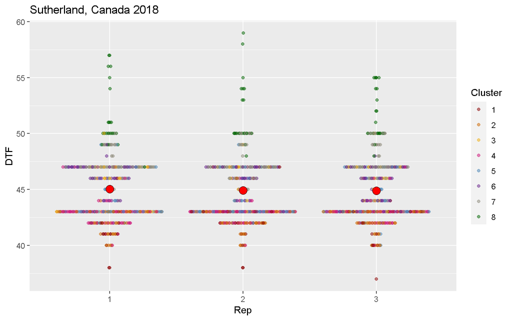

```r
# Plot
means <- xx %>% group_by(Rep) %>% summarise(DTF = mean(DTF))
ggplot(xx, aes(x = Rep, y = DTF)) +
  geom_quasirandom(aes(color = Cluster), alpha = 0.5) +
  geom_point(data = means, fill = "red", size = 4, pch = 21) +
  scale_color_manual(values = colors) +
  labs(title = "Sutherland, Canada 2018")
```

# Two-way ANOVA

```r
model <- lm(DTF ~ Cluster + Rep, data = xx)
anova(model)
```

```
## Analysis of Variance Table
##
## Response: DTF
##            Df Sum Sq Mean Sq F value Pr(>F)
## Cluster     7 6414.4  916.35 356.506 <2e-16 ***
## Rep         2    4.9    2.45   0.954 0.3856
## Residuals 957 2459.8    2.57
## ---
## Signif. codes:  0 '***' 0.001 '**' 0.01 '*' 0.05 '.' 0.1 ' ' 1
```

Now lets add an interaction term

```r
model <- lm(DTF ~ Cluster + Rep + Cluster:Rep, data = xx)
anova(model)
```

```
## Analysis of Variance Table
##
## Response: DTF
##              Df Sum Sq Mean Sq  F value Pr(>F)
## Cluster       7 6414.4  916.35 353.5501 <2e-16 ***
## Rep           2    4.9    2.45   0.9461 0.3886
## Cluster:Rep  14   15.7    1.12   0.4333 0.9643
## Residuals   943 2444.1    2.59
## ---
## Signif. codes:  0 '***' 0.001 '**' 0.01 '*' 0.05 '.' 0.1 ' ' 1
```

is the same as

```r
model <- lm(DTF ~ Cluster * Rep, data = xx)
anova(model)
```

```
## Analysis of Variance Table
##
## Response: DTF
##              Df Sum Sq Mean Sq  F value Pr(>F)
## Cluster       7 6414.4  916.35 353.5501 <2e-16 ***
## Rep           2    4.9    2.45   0.9461 0.3886
## Cluster:Rep  14   15.7    1.12   0.4333 0.9643
## Residuals   943 2444.1    2.59
## ---
## Signif. codes:  0 '***' 0.001 '**' 0.01 '*' 0.05 '.' 0.1 ' ' 1
```

```r
# Prep data
locs <- c("Sutherland, Canada", "Rosthern, Canada")
xx <- rr %>% filter(Location %in% locs, Cluster == 4:5)
# Run ANOVA
model <- lm(VEG ~ Year * Cluster, data = xx)
anova(model)
```

```
## Analysis of Variance Table
##
## Response: VEG
##               Df Sum Sq Mean Sq  F value Pr(>F)
## Year           2 1319.0  659.52 139.8379 <2e-16 ***
## Cluster        1    2.1    2.09   0.4436 0.5056
## Year:Cluster   2   12.0    6.01   1.2736 0.2805
## Residuals    687 3240.1    4.72
## ---
## Signif. codes:  0 '***' 0.001 '**' 0.01 '*' 0.05 '.' 0.1 ' ' 1
```

```r
# Prep data
locs <- c("Sutherland, Canada", "Rosthern, Canada")
xx <- rr %>% filter(Location %in% locs, Cluster == 7:8)
# Run ANOVA
model <- lm(VEG ~ Year * Cluster, data = xx)
anova(model)
```

```
## Analysis of Variance Table
##
## Response: VEG
##               Df Sum Sq Mean Sq  F value Pr(>F)
## Year           2 2214.3 1107.15 177.9276 <2e-16 ***
## Cluster        1 1964.0 1963.96 315.6238 <2e-16 ***
## Year:Cluster   2   13.8    6.89   1.1067 0.3313
## Residuals    628 3907.7    6.22
## ---
## Signif. codes:  0 '***' 0.001 '**' 0.01 '*' 0.05 '.' 0.1 ' ' 1
```

```r
# Prep data
locs <- c("Sutherland, Canada", "Rosthern, Canada")
xx <- rr %>% filter(Location %in% locs, Cluster == 7:8)
# Run ANOVA
model <- lm(VEG ~ Year * Cluster, data = xx)
anova(model)
```

```
## Analysis of Variance Table
##
## Response: VEG
##               Df Sum Sq Mean Sq  F value Pr(>F)
## Year           2 2214.3 1107.15 177.9276 <2e-16 ***
## Cluster        1 1964.0 1963.96 315.6238 <2e-16 ***
## Year:Cluster   2   13.8    6.89   1.1067 0.3313
## Residuals    628 3907.7    6.22
## ---
## Signif. codes:  0 '***' 0.001 '**' 0.01 '*' 0.05 '.' 0.1 ' ' 1
```

```r
model <- lmer(VEG ~ Year * Cluster + (1|Year/Rep), data = xx)
anova(model)
```

```
## Analysis of Variance Table
##              npar  Sum Sq Mean Sq  F value
## Year            2   28.66   14.33   2.3275
## Cluster         1 1963.76 1963.76 318.9208
## Year:Cluster    2   12.87    6.44   1.0454
```

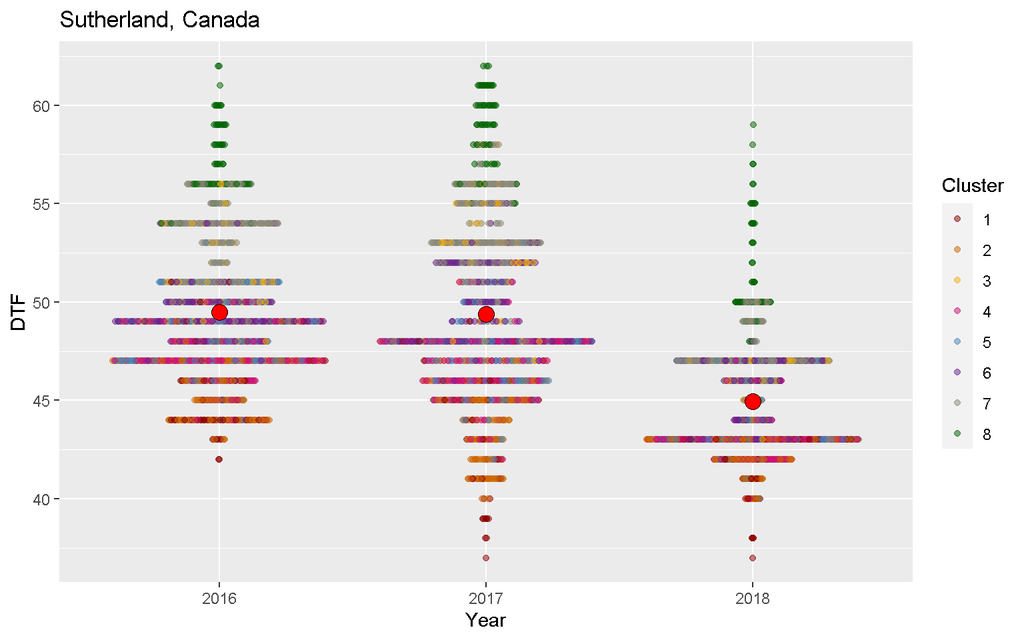

```r
# Prep data
xx <- rr %>% filter(Location == "Sutherland, Canada")
means <- xx %>% group_by(Year) %>% summarise(DTF = mean(DTF))
# Plot
ggplot(xx, aes(x = Year, y = DTF)) +
  geom_quasirandom(aes(color = Cluster), alpha = 0.5) +
  geom_point(data = means, fill = "red", size = 4, pch = 21) +
  scale_color_manual(values = colors) +
  labs(title = "Sutherland, Canada")
```

```r
#
model <- lm(DTF ~ Year, data = xx)
anova(model)
```

```
## Analysis of Variance Table
##
## Response: DTF
##             Df Sum Sq Mean Sq F value    Pr(>F)
## Year         2  12976  6487.8  418.25 < 2.2e-16 ***
## Residuals 2878  44643    15.5
## ---
## Signif. codes:  0 '***' 0.001 '**' 0.01 '*' 0.05 '.' 0.1 ' ' 1
```

```r
pairwise.t.test(xx$DTF, xx$Year, p.adj = "bonf")
```

```
##
##  Pairwise comparisons using t tests with pooled SD
##
## data:  xx$DTF and xx$Year
##
##      2016   2017
## 2017 1      -
## 2018 <2e-16 <2e-16
##
## P value adjustment method: bonferroni
```

```r
#
xx <- rr %>% filter(Location == "Sutherland, Canada")
model <- lmer(DTF ~ Name + Year + (1 | Rep), data = xx)
anova(model)
```

```
## Analysis of Variance Table
##      npar Sum Sq Mean Sq  F value
## Name  323  37945   117.5   47.103
## Year    2  13023  6511.7 2610.962
```

… To Be Continued …

# Nepal

y ~ x1*x2 + (1|x2/r1/b1)